# Unit 2 Module 2b

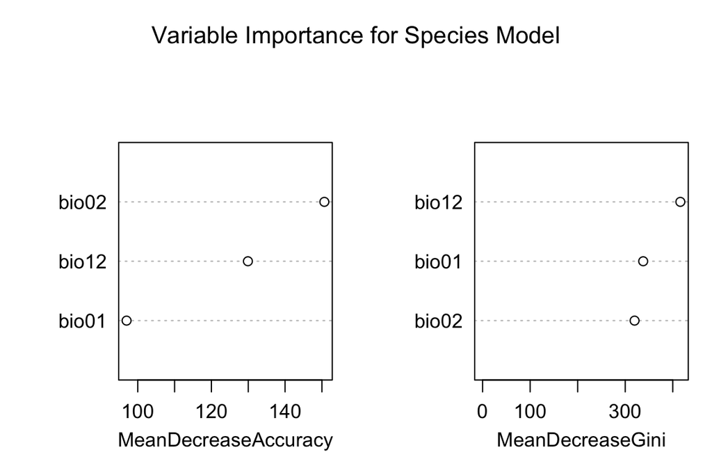

```r
# #10. Visualize Variable Importance
# This shows which of our 3 bioclim vars was most influential
varImpPlot(mod_rf, main = "Variable Importance for Species Model")
```

This example demonstrates a very crude species distribution model (SDM) that uses bio01 (annual mean temperature), bio02 (mean diurnal range), and bio12 (annual precipitation) to predict the habitat suitability of African buffalo in Tanzania. In actual ecological work, the modeling process would be significantly more complex to ensure the results are biologically meaningful. Professional workflows typically involve rigorous steps such as accounting for sampling bias, testing for multicollinearity among predictors, and using independent datasets for validation to prevent the overfitting issues mentioned above. Here, we are simply demonstrating the core spatial mechanics of the SDM workflow.

Let’s examine the code a bit:

Block #1 subsets the `species` data for our target species and converts the coordinates into a spatial `sf` object. Importantly, we ensure the coordinate reference system (CRS) matches our environmental layers.

Block #2 selects our three relevant bioclimatic predictors from the `bioclimz` stack. In #3, we generate 1,000 random “background” points (pseudo-absences) across the extent of the predictors. This is necessary because we only have presence records, and the model needs to compare these against the available environmental conditions across Tanzania.

In #4, we use `terra::extract` to pull the values of our three predictors for both the known sightings and the random background points. We then combine these into a single training data frame, using #5 to create a response variable `pa` where presences are coded as 1 and background points as 0.

Block #6 (in your next chunk) uses the `randomForest` function to fit the model. We treat the response as a `factor` to perform classification, using “bio01, bio02, and bio12” to predict the probability of buffalo occurrence.

Finally, in block #9 and #10, we assessed the model performance. Our model achieved an AUC of 0.9994877, which indicates an exceptionally high ability to distinguish between presence and background locations. But an AUC of 0.9994877 is also a strong signal that we must be careful of overfitting in actual ecological work.

The variable importance plot summarizes two different measures of how much each bioclimatic factor contributes to the model: the Mean Decrease in Accuracy and the Mean Decrease in Gini (node impurity). Accuracy decreases if a variable is shuffled and the model loses its predictive power, whereas Gini impurity declines when a variable is highly effective at splitting the “presence” and “background” points into clean, distinct groups. Looking at the importance plot in #10, we see that bio02 (Mean Diurnal Range) has the highest Mean Decrease in Accuracy, while bio12 (Annual Precipitation) has the highest Mean Decrease in Gini. This suggests that while precipitation is very efficient at creating the initial broad splits in our decision trees, the daily temperature fluctuations are ultimately the most critical for the model’s overall predictive precision.

So that’s about it for this module.

## 2.5 Practice

### 2.5.1 Questions

1. How do we estimate the pixel area of rasters when they are in non-projected coordinate systems?
2. How can you add mathematical symbols and other special characters (e.g. superscripts) to graphics?
3. When you want to apply a fitted model to a multi-layer raster (e.g. `pred_stack` that provide the model predictor layers, what do we have to remember to do with `names(pred_stack)`?

### 2.5.2 Code

1. Crop `demalb` down to the extent of district 145 (bear in mind that `districts` needs to be in the same projection as `demalb`, so transform it first). Then calculate slope, aspect, and TPI on the cropped DEM. Plot the results so that they appear in 3 side by side panels.
2. Using the code in Chunk 46 blocks #1-#3 as your template, re-create IDW interpolations using the original 1000 randomly sampled points. Then create two new ones based on 1) 500 and 2) 250 randomly selected points (use the same seed). Stacking the results in this order: `raintotalb`, the 1000 point IDW, the 500 point IDW, and the 250 IDW. Plot these in a single call to `plot_noaxes`, setting `zlim = c(0, 150)` and passing informative titles to the “main” argument (e.g. “bio12”, “1000 pt IDW”, “500 pt IDW”, etc). There are two ways of doing this: i) the hard way, by copying, pasting, and changing code blocks #2 and #3 for each version of the IDW; ii) the programmatic way, by creating the three IDWs in an `lapply`. Note: if you choose the elegant way, to make the stack, you will either need to `c(raintotalb, idw_list)` or `c(raintotalb, c(idw_list))` stack the list of three idws, and then stack that with `raintotalb`.
3. Select (`filter`) districts 15, 20, 25, 30, 35, 40, 45, and 50 out of `districts`. Convert the resulting subset of districts to Albers projection, and then extract the centroids of those districts. Using `raintotalb` as your target, use `distance` to calculate the distances from any point in Tanzania to the centroids of those selected districts. Mask the result (you can use `raintotalb` again for the mask target) and plot it using `plot_noaxes`.
4. Redo the code in Chunk 48, but use a new random draw of just 100 background to get `bg_pts` (ref. #3). How much more would the results change compared to a model with denser background?

# 3 Unit assignment

## 3.1 Set-up

Make sure you are working in the main branch of your project (you should not be working on the a4 branch). Create a new vignette named “unit2-module2.Rmd”. You will use this to document the tasks you undertake for this assignment.

There are no package functions to create for this assignment. All work is to be done in the vignette.

## 3.2 Vignette tasks

1. Create a subset of `districts` (of course you have to read `districts`) by extracting districts 40, 95, 73, 145. Call it `districts_ss`. Use the extent of `districts_ss` (`ext(districts_ss)`) and crs of `districts_ss` to define the extent of a new raster `r`, which should have a resolution of 0.1°. Use this `r` as a template for creating two new rasters, `rsamp` and `rrandn`. `rsamp` should be filled with randomly selected integers ranging between 10 and 50. `rrandn` should be filled with random numbers drawn from a normal distribution (`rnorm`) that has a mean of 30 and standard deviation of 5. Use **a seed of 1** in `set.seed` for both rasters. Stack `rsamp` and `rrandn` (name the stack `s`), mask that by `districts_ss`, and plot `s` using `plot_noaxes` (This function has been included in package `sdadata`, so you need to load it first). (Ref: Chunks 1, 3, 4, 16 in Unit2-Module2a)
2. Disaggregate `s[[1]]` to a resolution of 0.025°, using bilinear interpolation, calling the result `s2_1d`. Select all areas of `s2_1d` that have values > 35, creating a new raster `s2_1gt35`. Set the values of `s2_1gt35` that equal 0 to NA. Then convert the resulting raster into an `sf` object called `s2poly`. Plot the resulting polygons over `s2_1d`. (Ref: Chunks 10, 22, 37)
3. Create a new grid from the extent of `districts` that has a resolution of 0.5° (call it `tzar`), assigning all cells a value of 1. Then recreate the `speciesr` dataset–a raster that sums the number of species falling within each grid cell. Mask the results using `districts`, and then plot the result onto a grey background of Tanzania using `plot_noaxes` (Reminder: you may need to set argument `ext` for `plot_noaxes`). (Ref: Chunk 1, 8, 37)
4. Convert the rasterized species counts (`speciesr`) back into an `sf` points object `speciesrpts`. Create a new version of `tzar` at 0.05°, and then calculate the distance between these points and every other location in Tanzania, creating an output grid of distances, called `dist_to_species`, which you mask by `districts`. Plot `dist_to_species` in kilometers (i.e. divide it by 1000) using `plot_no_axes`, with `speciesrpts` overlaid as black solid circles. (Ref: Chunks 8, 10, 47)
5. Use `geodata`’s `worldclim_country` function to grab WorldClim’s mean temperature (“tavg”) dataset at a resolution of 2.5 (note this is not degrees, but minutes of a degree), and download it to somewhere on your local disk. That will give a `SpatRaster` with 12 layers, with each layer representing the average monthly temperature for each grid cell on the planet. Calculate the annual mean temperature for each cell, and then mask the result using `districts` to get your final raster, `tzatmean`. Plot the result. (Ref: Chunk 17, 35)
6. Classify the temperature data into three categories, low, medium, and high, using <20°, 20-24°, and >24° as the break points for determining the classes. Use the `classify` function with a reclassification matrix, which you should do like this:

   ```r
   trng <- global(tzatmean, range, na.rm = TRUE)
   cuts <- c(floor(trng[1, 1]), 20, 24, ceiling(trng[1, 2]))
   ```

   Here `global` is helping to find the values of tmin and tmax, which respectively define the lower bound of the “low” class and the upper bound of the “high” class. What are the functions `floor` and `ceiling` doing (**answer this in your vignette**)? Call the reclassified temperature raster `tzatclass`. Make the map using `geom_spatraster` with a categorical legend (using `scale_fill_manual`), and using the colors “blue”, “yellow2”, and “red” for the three classes. (Ref: Chunk 26, 38)
7. Recreate the `precip` layer (`precip <- bioclimz[["bio12"]]`, see the beginning chunk and chunk37 in unit2-module2b), then calculate the mean precipitation within each temperature zone defined by `tzatclass` (hint: you will need to resample `precip` using function `resample`). Call the resulting matrix `z`. Map the mean zonal precipitation values in `z` onto each temperature zone (using the `subst` function with `tzatclass` as the target; remember that `zonal` returns a matrix, and that `subst` requires equal length vector for the “from” and “to” values. Call the new raster `tzaprecz`, and then plot it using `geom_spatraster`, with a custom legend (as done in Task 6), using the rounded zonal precipitation values (rounded) as the legend labels (`labels = round(z$bio12)` in `scale_fill_manual`). Use colors “yellow2”, “green3”, and “blue” for the three classes. (Ref: Chunks 32, 33, 38)
8. Use `geodata::elevation_30s` again to download the elevation raster for Tanzania (call it `dem`). Aggregate it with `fact = 5` and call the result `dem5`. Use `terrain` to calculate aspect from `dem5` (call it `aspect`), selecting degrees as the output value. Then find all west-facing aspects (aspects >247.5 and <292.5), and all east facing aspects (>67.5 and <112.5), making new rasters respectively named `west` and `east`, e.g. `west <- aspect > 247.5 & aspect < 292.5)`. Stack these together with `aspect` and make a three-panel plot with `plot_noaxes` with titles “Aspect”, “West”, and “East”. (Ref: Chunks 37, 42)
9. Using a random seed of 1, create two random samples of 100 each. The first one should be collected from within the west-facing cells (i.e. only be drawn from cells in `west` that have a cell of one), and the second from east-facing cells. To do this, set the cells equal to 0 in `east` and `west` to NA (e.g. `west[west == 0] <- NA`). Once you have collected those, convert the resulting objects to `sf`, and use those two sets of points to extract temperature values from `tzatmean` into a tibble `temp_stats`, which is going to look this:

   ```r
   temp_stats <- bind_rows(
       tibble(temp = terra::extract(tzatmean, westpts)[, 2], dat = "West"),
       tibble(temp = terra::extract(tzatmean, eastpts)[, 2], dat = "East")) %>%
       na.omit()
   ```

   Then use `temp_stats` with `ggplot` to make side-by-side boxplots to compare the distributions of west and east facing temperatures, modeled on the example in Chunk 40 #4. (Ref: Chunks 37, 40, 41)
10. **Extra credit worth (5 points).** Extract the centroids from each district in `districts` (call it `dcent`), and reproject the points to Albers, using the `st_crs(roads)` (You have to load `roads` first). Reproject `tzatmean` to Albers also, making the new resolution (5 km, i.e. 5000 m), using bilinear interpolation (call it `tzatmeanalb`). Then use `dcent` to extract the temperature values from `tzatmeanalb` (add the values to `dcent` as a new variable “temp” using `mutate`). Use `gstat` to create an IDW model (call it `idw`). To make the IDW work, which isn’t `sf` compliant, some extra work will be required, as shown below (this is the step needed after the extract of temperature values)

    ```r
    dcent <- bind_cols(
      dcent %>% data.frame %>% dplyr::select(-geometry) %>% as_tibble,
      st_coordinates(dcent) %>% as_tibble
    ) %>% rename(x = X, y = Y)
    ```

    This yields a `tibble` with columns *x* and *y* that are needed by `gstat`. After running `gstat`, map the interpolated temperatures using `tzatmeanalb` as a target object (it won’t be overwritten) and `idw` as the model. Make sure you mask the result (just the prediction) to the boundaries of Tanzania, using `tzatmeanalb` as the mask. Call the new interpolated, masked grid `tzatidw`. Plot the result side by side with `tzatmeanalb` for comparison using `plot_noaxes` with titles “Real Temperature” and “IDW Temperature”. (Refs: Chunks 46)

## 3.3 Assignment output

Refer to Unit 1 Module 4’s assignment output section for submission instructions. The only differences are as follows:

1. You should increment your package version number by 1 on the lowest number (e.g. from 0.1.3 to 0.1.4) in the DESCRIPTION;
2. Revise the setting chunk in the beginning of your vignette to:

   ```markdown
   knitr::opts_chunk$set(
     collapse = TRUE,
     comment = "#>",
     warning = FALSE,
     message = FALSE,
     fig.align = 'center',
     fig.height = 4,
     fig.width = 6
   )
   ```

   to avoid unnecessary warning and message and set global values for figure height and width.
3. Update vignette title and this line in the YAML header to `%\VignetteIndexEntry{Unit 2 Module 2 assignment 5}`. When you browse the vignettes of your package, you should see a page in your browser like this:

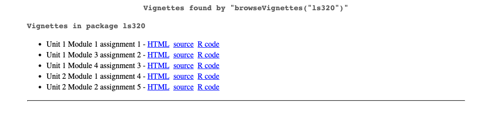

4. Your submission should be on a new side branch “a5”.

Back to home